# Quick reference: data.table

Taehoon Ha

7/15/2019

### 1. Package loading

```r
library(data.table)
```

### 2. Example data: flights

```r
flights <- fread("Data/flights.csv")
head(flights) %>% knitr::kable()
```

| YEAR | MONTH | DAY | DAY_OF_WEEK | AIRLINE | FLIGHT_NUMBER | TAIL_NUMBER | ORIGIN_AIRPORT | DESTINATION_AIRPORT | SCHEDULED_DEPARTURE | DEPARTURE_TIME | DEPARTURE_DELAY | TAXI_OUT | WHEELS_OFF | SCHEDULED_TIME | ELAPSED_TIME | AIR_TIME | DISTANCE | WHEELS_ON | TAXI_IN | SCHEDULED_ARRIVAL | ARRIVAL_TIME | ARRIVAL_DELAY | DIVERTED | CANCELLED | CANCELLATION_REASON | AIR_SYSTEM_DELAY | SECURITY_DELAY | AIRLINE_DELAY | LATE_AIRCRAFT_DELAY | … |
| --- | --- | --- | --- | --- | --- | --- | --- | --- | --- | --- | --- | --- | --- | --- | --- | --- | --- | --- | --- | --- | --- | --- | --- | --- | --- | --- | --- | --- | --- | --- |
| 2015 | 1 | 1 | 4 | AS | 98 | N407AS | ANC | SEA | 5 | 2354 | -11 | 21 | 15 | 205 | 194 | 169 | 1448 | 404 | 4 | 430 | 408 | -22 | 0 | 0 |  | NA | NA | NA | NA | … |
| 2015 | 1 | 1 | 4 | AA | 2336 | N3KUAA | LAX | PBI | 10 | 2 | -8 | 12 | 14 | 280 | 279 | 263 | 2330 | 737 | 4 | 750 | 741 | -9 | 0 | 0 |  | NA | NA | NA | NA | … |
| 2015 | 1 | 1 | 4 | US | 840 | N171US | SFO | CLT | 20 | 18 | -2 | 16 | 34 | 286 | 293 | 266 | 2296 | 800 | 11 | 806 | 811 | 5 | 0 | 0 |  | NA | NA | NA | NA | … |
| 2015 | 1 | 1 | 4 | AA | 258 | N3HYAA | LAX | MIA | 20 | 15 | -5 | 15 | 30 | 285 | 281 | 258 | 2342 | 748 | 8 | 805 | 756 | -9 | 0 | 0 |  | NA | NA | NA | NA | … |
| 2015 | 1 | 1 | 4 | AS | 135 | N527AS | SEA | ANC | 25 | 24 | -1 | 11 | 35 | 235 | 215 | 199 | 1448 | 254 | 5 | 320 | 259 | -21 | 0 | 0 |  | NA | NA | NA | NA | … |
| 2015 | 1 | 1 | 4 | DL | 806 | N3730B | SFO | MSP | 25 | 20 | -5 | 18 | 38 | 217 | 230 | 206 | 1589 | 604 | 6 | 602 | 610 | 8 | 0 | 0 |  | NA | NA | NA | NA | … |

### 3. What is `data.table`?

```r
class(flights)
```

```
## [1] "data.table" "data.frame"
```

> It is an extension of the `data.frame` class.

### 4. Subsetting a `data.table`

$$DT[i, j, by] \\
\begin{aligned}
i&: \text{filters rows (analagous to a WHERE clause in SQL)} \\
j&: \text{is how you select/compute on columns} \\
by&: \text{is where you can group computations} \end{aligned}$$

#### 1) $i$

- first index is ALWAYS rows, regardless of commas

```r
identical(flights[2], flights[2,])
```

```
## [1] TRUE
```

- Compare to `data.frame`

```r
as.data.frame(flights)[2]  %>% dim
```

```
## [1] 5819079       1
```

```r
as.data.frame(flights)[2,] %>% dim
```

```
## [1]  1 31
```

- Use $i$ to select rows

```r
flights[1:2] # first and second row
```

```
##    YEAR MONTH DAY DAY_OF_WEEK AIRLINE FLIGHT_NUMBER TAIL_NUMBER
## 1: 2015     1   1           4      AS            98      N407AS
## 2: 2015     1   1           4      AA          2336      N3KUAA
##    ORIGIN_AIRPORT DESTINATION_AIRPORT SCHEDULED_DEPARTURE DEPARTURE_TIME
## 1:            ANC                 SEA                   5           2354
## 2:            LAX                 PBI                  10              2
##    DEPARTURE_DELAY TAXI_OUT WHEELS_OFF SCHEDULED_TIME ELAPSED_TIME
## 1:             -11       21         15            205          194
## 2:              -8       12         14            280          279
##    AIR_TIME DISTANCE WHEELS_ON TAXI_IN SCHEDULED_ARRIVAL ARRIVAL_TIME
## 1:      169     1448       404       4               430          408
## 2:      263     2330       737       4               750          741
##    ARRIVAL_DELAY DIVERTED CANCELLED CANCELLATION_REASON AIR_SYSTEM_DELAY
## 1:           -22        0         0                                   NA
## 2:            -9        0         0                                   NA
##    SECURITY_DELAY AIRLINE_DELAY LATE_AIRCRAFT_DELAY WEATHER_DELAY
## 1:             NA            NA                  NA            NA
## 2:             NA            NA                  NA            NA
```

```r
flights[2:1] # second and first row
```

```
##    YEAR MONTH DAY DAY_OF_WEEK AIRLINE FLIGHT_NUMBER TAIL_NUMBER
## 1: 2015     1   1           4      AA          2336      N3KUAA
## 2: 2015     1   1           4      AS            98      N407AS
##    ORIGIN_AIRPORT DESTINATION_AIRPORT SCHEDULED_DEPARTURE DEPARTURE_TIME
## 1:            LAX                 PBI                  10              2
## 2:            ANC                 SEA                   5           2354
##    DEPARTURE_DELAY TAXI_OUT WHEELS_OFF SCHEDULED_TIME ELAPSED_TIME
## 1:              -8       12         14            280          279
## 2:             -11       21         15            205          194
##    AIR_TIME DISTANCE WHEELS_ON TAXI_IN SCHEDULED_ARRIVAL ARRIVAL_TIME
## 1:      263     2330       737       4               750          741
## 2:      169     1448       404       4               430          408
##    ARRIVAL_DELAY DIVERTED CANCELLED CANCELLATION_REASON AIR_SYSTEM_DELAY
## 1:            -9        0         0                                   NA
## 2:           -22        0         0                                   NA
##    SECURITY_DELAY AIRLINE_DELAY LATE_AIRCRAFT_DELAY WEATHER_DELAY
## 1:             NA            NA                  NA            NA
## 2:             NA            NA                  NA            NA
```

- Logical expressions

```r
flights[MONTH == 1]
flights[MONTH == 1 & DISTANCE > 1000]
```

- `identical()` function

```r
identical(flights[-1:-100000], flights[!1:100000])
```

```
## [1] TRUE
```

- `order()`: optimized within a `data.table`
> - makes sorting a cinch
> - sort by one column and then another
> - minus (‘-’) means descending order

```r
flights[order(TAIL_NUMBER,-ARRIVAL_DELAY)] %>% head() %>% knitr::kable()
```

| YEAR | MONTH | DAY | DAY_OF_WEEK | AIRLINE | FLIGHT_NUMBER | TAIL_NUMBER | ORIGIN_AIRPORT | DESTINATION_AIRPORT | SCHEDULED_DEPARTURE | DEPARTURE_TIME | DEPARTURE_DELAY | TAXI_OUT | WHEELS_OFF | SCHEDULED_TIME | ELAPSED_TIME | AIR_TIME | DISTANCE | WHEELS_ON | TAXI_IN | SCHEDULED_ARRIVAL | ARRIVAL_TIME | ARRIVAL_DELAY | DIVERTED | CANCELLED | CANCELLATION_REASON | AIR_SYSTEM_DELAY | SECURITY_DELAY | AIRLINE_DELAY | LATE_AIRCRAFT_DELAY | … |
| --- | --- | --- | --- | --- | --- | --- | --- | --- | --- | --- | --- | --- | --- | --- | --- | --- | --- | --- | --- | --- | --- | --- | --- | --- | --- | --- | --- | --- | --- | --- |
| 2015 | 1 | 1 | 4 | F9 | 865 |  | MSO | DEN | 600 | NA | NA | NA | NA | 120 | NA | NA | 679 | NA | NA | 800 | NA | NA | 0 | 1 | A | NA | NA | NA | NA | … |
| 2015 | 1 | 1 | 4 | F9 | 1256 |  | ORD | MIA | 600 | NA | NA | NA | NA | 180 | NA | NA | 1197 | NA | NA | 1000 | NA | NA | 0 | 1 | A | NA | NA | NA | NA | … |
| 2015 | 1 | 1 | 4 | UA | 641 |  | LAX | HNL | 845 | NA | NA | NA | NA | 344 | NA | NA | 2556 | NA | NA | 1229 | NA | NA | 0 | 1 | A | NA | NA | NA | NA | … |
| 2015 | 1 | 1 | 4 | UA | 1412 |  | ORD | PHL | 1010 | NA | NA | NA | NA | 121 | NA | NA | 678 | NA | NA | 1311 | NA | NA | 0 | 1 | A | NA | NA | NA | NA | … |
| 2015 | 1 | 1 | 4 | US | 1883 |  | SLC | PHL | 1030 | NA | NA | NA | NA | 243 | NA | NA | 1927 | NA | NA | 1633 | NA | NA | 0 | 1 | A | NA | NA | NA | NA | … |
| 2015 | 1 | 1 | 4 | F9 | 1257 |  | MIA | ORD | 1050 | NA | NA | NA | NA | 200 | NA | NA | 1197 | NA | NA | 1310 | NA | NA | 0 | 1 | A | NA | NA | NA | NA | … |

> sort by a function on our data

```r
flights[order(substr(ORIGIN_AIRPORT,1,1))] %>% head %>% knitr::kable()
```

| YEAR | MONTH | DAY | DAY_OF_WEEK | AIRLINE | FLIGHT_NUMBER | TAIL_NUMBER | ORIGIN_AIRPORT | DESTINATION_AIRPORT | SCHEDULED_DEPARTURE | DEPARTURE_TIME | DEPARTURE_DELAY | TAXI_OUT | WHEELS_OFF | SCHEDULED_TIME | ELAPSED_TIME | AIR_TIME | DISTANCE | WHEELS_ON | TAXI_IN | SCHEDULED_ARRIVAL | ARRIVAL_TIME | ARRIVAL_DELAY | DIVERTED | CANCELLED | CANCELLATION_REASON | AIR_SYSTEM_DELAY | SECURITY_DELAY | AIRLINE_DELAY | LATE_AIRCRAFT_DELAY | … |
| --- | --- | --- | --- | --- | --- | --- | --- | --- | --- | --- | --- | --- | --- | --- | --- | --- | --- | --- | --- | --- | --- | --- | --- | --- | --- | --- | --- | --- | --- | --- |
| 2015 | 10 | 1 | 4 | AA | 1230 | N3DBAA | 14747 | 11298 | 5 | 15 | 10 | 15 | 30 | 237 | 208 | 189 | 1660 | 539 | 4 | 602 | 543 | -19 | 0 | 0 |  | NA | NA | NA | NA | … |
| 2015 | 10 | 1 | 4 | DL | 1805 | N696DL | 14771 | 13487 | 5 | 16 | 11 | 14 | 30 | 213 | 192 | 171 | 1589 | 521 | 7 | 538 | 528 | -10 | 0 | 0 |  | NA | NA | NA | NA | … |
| 2015 | 10 | 1 | 4 | NK | 612 | N602NK | 12889 | 13487 | 5 | 2400 | -5 | 15 | 15 | 177 | 168 | 149 | 1299 | 444 | 4 | 502 | 448 | -14 | 0 | 0 |  | NA | NA | NA | NA | … |
| 2015 | 10 | 1 | 4 | AA | 260 | N3GNAA | 12892 | 13303 | 10 | 7 | -3 | 28 | 35 | 296 | 306 | 271 | 2342 | 806 | 7 | 806 | 813 | 7 | 0 | 0 |  | NA | NA | NA | NA | … |
| 2015 | 10 | 1 | 4 | AA | 1982 | N914UY | 14771 | 11057 | 10 | 8 | -2 | 12 | 20 | 291 | 282 | 257 | 2296 | 737 | 13 | 801 | 750 | -11 | 0 | 0 |  | NA | NA | NA | NA | … |
| 2015 | 10 | 1 | 4 | UA | 684 | N495UA | 14771 | 13930 | 14 | 13 | -1 | 12 | 25 | 261 | 229 | 212 | 1846 | 557 | 5 | 635 | 602 | -33 | 0 | 0 |  | NA | NA | NA | NA | … |

- chain queries together

```r
flights[!is.na(ARRIVAL_DELAY)][order(TAIL_NUMBER,-ARRIVAL_DELAY)] %>% head() %>% knitr::kable()
```

| YEAR | MONTH | DAY | DAY_OF_WEEK | AIRLINE | FLIGHT_NUMBER | TAIL_NUMBER | ORIGIN_AIRPORT | DESTINATION_AIRPORT | SCHEDULED_DEPARTURE | DEPARTURE_TIME | DEPARTURE_DELAY | TAXI_OUT | WHEELS_OFF | SCHEDULED_TIME | ELAPSED_TIME | AIR_TIME | DISTANCE | WHEELS_ON | TAXI_IN | SCHEDULED_ARRIVAL | ARRIVAL_TIME | ARRIVAL_DELAY | DIVERTED | CANCELLED | CANCELLATION_REASON | AIR_SYSTEM_DELAY | SECURITY_DELAY | AIRLINE_DELAY | LATE_AIRCRAFT_DELAY | … |
| --- | --- | --- | --- | --- | --- | --- | --- | --- | --- | --- | --- | --- | --- | --- | --- | --- | --- | --- | --- | --- | --- | --- | --- | --- | --- | --- | --- | --- | --- | --- |
| 2015 | 9 | 25 | 5 | WN | 2736 | 7819A | DSM | MDW | 550 | 1321 | 451 | 11 | 1332 | 80 | 65 | 50 | 306 | 1422 | 4 | 710 | 1426 | 436 | 0 | 0 |  | 0 | 0 | 436 | 0 | … |
| 2015 | 8 | 5 | 3 | WN | 815 | 7819A | GEG | DEN | 540 | 1250 | 430 | 8 | 1258 | 130 | 121 | 106 | 836 | 1544 | 7 | 850 | 1551 | 421 | 0 | 0 |  | 0 | 0 | 421 | 0 | … |
| 2015 | 11 | 21 | 6 | WN | 2279 | 7819A | ALB | MCO | 1805 | 2324 | 319 | 11 | 2335 | 190 | 180 | 164 | 1073 | 219 | 5 | 2115 | 224 | 309 | 0 | 0 |  | 0 | 0 | 25 | 284 | … |
| 2015 | 11 | 21 | 6 | WN | 2279 | 7819A | MDW | ALB | 1450 | 1932 | 282 | 30 | 2002 | 105 | 116 | 83 | 717 | 2225 | 3 | 1735 | 2228 | 293 | 0 | 0 |  | 11 | 0 | 0 | 245 | … |
| 2015 | 7 | 22 | 3 | WN | 840 | 7819A | PHL | MCO | 1650 | 1943 | 173 | 10 | 1953 | 155 | 129 | 112 | 861 | 2145 | 7 | 1925 | 2152 | 147 | 0 | 0 |  | 0 | 0 | 76 | 71 | … |
| 2015 | 7 | 22 | 3 | WN | 4636 | 7819A | MCO | RIC | 2000 | 2225 | 145 | 9 | 2234 | 110 | 105 | 91 | 667 | 5 | 5 | 2150 | 10 | 140 | 0 | 0 |  | 0 | 0 | 0 | 140 | … |

```r
flights %>%
  .[!is.na(ARRIVAL_DELAY)] %>%
  .[order(TAIL_NUMBER,-ARRIVAL_DELAY)] %>% head() %>% knitr::kable()
```

| YEAR | MONTH | DAY | DAY_OF_WEEK | AIRLINE | FLIGHT_NUMBER | TAIL_NUMBER | ORIGIN_AIRPORT | DESTINATION_AIRPORT | SCHEDULED_DEPARTURE | DEPARTURE_TIME | DEPARTURE_DELAY | TAXI_OUT | WHEELS_OFF | SCHEDULED_TIME | ELAPSED_TIME | AIR_TIME | DISTANCE | WHEELS_ON | TAXI_IN | SCHEDULED_ARRIVAL | ARRIVAL_TIME | ARRIVAL_DELAY | DIVERTED | CANCELLED | CANCELLATION_REASON | AIR_SYSTEM_DELAY | SECURITY_DELAY | AIRLINE_DELAY | LATE_AIRCRAFT_DELAY | … |
| --- | --- | --- | --- | --- | --- | --- | --- | --- | --- | --- | --- | --- | --- | --- | --- | --- | --- | --- | --- | --- | --- | --- | --- | --- | --- | --- | --- | --- | --- | --- |
| 2015 | 9 | 25 | 5 | WN | 2736 | 7819A | DSM | MDW | 550 | 1321 | 451 | 11 | 1332 | 80 | 65 | 50 | 306 | 1422 | 4 | 710 | 1426 | 436 | 0 | 0 |  | 0 | 0 | 436 | 0 | … |
| 2015 | 8 | 5 | 3 | WN | 815 | 7819A | GEG | DEN | 540 | 1250 | 430 | 8 | 1258 | 130 | 121 | 106 | 836 | 1544 | 7 | 850 | 1551 | 421 | 0 | 0 |  | 0 | 0 | 421 | 0 | … |
| 2015 | 11 | 21 | 6 | WN | 2279 | 7819A | ALB | MCO | 1805 | 2324 | 319 | 11 | 2335 | 190 | 180 | 164 | 1073 | 219 | 5 | 2115 | 224 | 309 | 0 | 0 |  | 0 | 0 | 25 | 284 | … |
| 2015 | 11 | 21 | 6 | WN | 2279 | 7819A | MDW | ALB | 1450 | 1932 | 282 | 30 | 2002 | 105 | 116 | 83 | 717 | 2225 | 3 | 1735 | 2228 | 293 | 0 | 0 |  | 11 | 0 | 0 | 245 | … |
| 2015 | 7 | 22 | 3 | WN | 840 | 7819A | PHL | MCO | 1650 | 1943 | 173 | 10 | 1953 | 155 | 129 | 112 | 861 | 2145 | 7 | 1925 | 2152 | 147 | 0 | 0 |  | 0 | 0 | 76 | 71 | … |
| 2015 | 7 | 22 | 3 | WN | 4636 | 7819A | MCO | RIC | 2000 | 2225 | 145 | 9 | 2234 | 110 | 105 | 91 | 667 | 5 | 5 | 2150 | 10 | 140 | 0 | 0 |  | 0 | 0 | 0 | 140 | … |

#### 2) $j$

- computations on columns

```r
# select columns by name in the second index parameter
flights[ , DESTINATION_AIRPORT] %>% head() %>% knitr::kable()           # as a vector
```

| x |
| --- |
| SEA |
| PBI |
| CLT |
| MIA |
| ANC |
| MSP |

```r
flights[ , list(DESTINATION_AIRPORT)] %>% head() %>% knitr::kable()     # as a data.table
```

| DESTINATION_AIRPORT |
| --- |
| SEA |
| PBI |
| CLT |
| MIA |
| ANC |
| MSP |

- use list to select multiple columns

```r
flights[ , list(DESTINATION_AIRPORT, ORIGIN_AIRPORT)] %>% head() %>% knitr::kable()
```

| DESTINATION_AIRPORT | ORIGIN_AIRPORT |
| --- | --- |
| SEA | ANC |
| PBI | LAX |
| CLT | SFO |
| MIA | LAX |
| ANC | SEA |
| MSP | SFO |

- `.()` is the same as `list()` in `data.table`

```r
flights[ , .(DESTINATION_AIRPORT, ORIGIN_AIRPORT)] %>% head() %>% knitr::kable()
```

| DESTINATION_AIRPORT | ORIGIN_AIRPORT |
| --- | --- |
| SEA | ANC |
| PBI | LAX |
| CLT | SFO |
| MIA | LAX |
| ANC | SEA |
| MSP | SFO |

- also computable on columns

```r
flights[ , unique(ORIGIN_AIRPORT)]  %>% head() %>% knitr::kable()
```

| x |
| --- |
| ANC |
| LAX |
| SFO |
| SEA |
| LAS |
| DEN |

```r
flights[ , sum(AIR_TIME, na.rm = TRUE) / (1e6 * 60)]  %>% head() %>% knitr::kable()
```

| x |
| --- |
| 10.81011 |

```r
flights[ , summary(as.factor(CANCELLATION_REASON))]  %>% head() %>% knitr::kable()
```

|  | x |
| --- | --- |
|  | 5729195 |
| A | 25262 |
| B | 48851 |
| C | 15749 |
| D | 22 |

```r
flights[ , .(AIR_TIME, AIR_TIME/60)] %>% head() %>% knitr::kable()# return multiple columns
```

| AIR_TIME | V2 |
| --- | --- |
| 169 | 2.816667 |
| 263 | 4.383333 |
| 266 | 4.433333 |
| 258 | 4.300000 |
| 199 | 3.316667 |
| 206 | 3.433333 |

- name the items

```r
flights[ , .(AIR_TIME, AIR_TIME_HOURS = AIR_TIME/60)] %>% head() %>% knitr::kable()
```

| AIR_TIME | AIR_TIME_HOURS |
| --- | --- |
| 169 | 2.816667 |
| 263 | 4.383333 |
| 266 | 4.433333 |
| 258 | 4.300000 |
| 199 | 3.316667 |
| 206 | 3.433333 |

> Anytime the $j$ expression returns a list, the whole expression will return a `data.table`.

#### 3) $i$ and $j$

##### Q1. How many flights were delayed touching down?

```r
flights[ARRIVAL_DELAY>0, .N]
```

```
## [1] 2086896
```

> `.N` is a convenience symbol to get the number of rows in a `data.table`

##### Q2. What are some summary statistics of the delayed flights (in hours)?

```r
flights[ARRIVAL_DELAY>0, summary(ARRIVAL_DELAY/60)]
```

```
##     Min.  1st Qu.   Median     Mean  3rd Qu.     Max.
##  0.01667  0.10000  0.25000  0.55188  0.63333 32.85000
```

##### Q3. How many flights were on each day of the week?

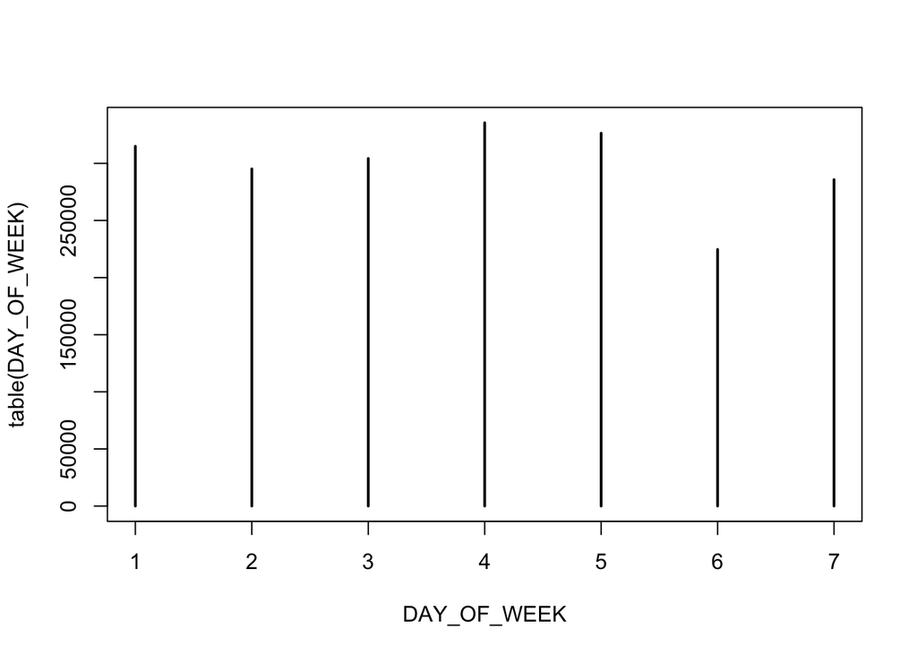

```
## [1] 1 2 3 4 5 6 7
```

```r
flights[ARRIVAL_DELAY>0, plot(table(DAY_OF_WEEK))]
```

> - we don’t have to return a `data.table`
> - an expression that returns a list in $j$ would, but here we want to plot, and `data.table` evaluates the expression correctly.

#### 4) `by`: grouping

##### Q4. How many outgoing flights did each aiport have?

```r
flights[ , .N, by = ORIGIN_AIRPORT] %>% head() %>% knitr::kable()
```

| ORIGIN_AIRPORT | N |
| --- | --- |
| ANC | 16005 |
| LAX | 194673 |
| SFO | 148008 |
| SEA | 110899 |
| LAS | 133181 |
| DEN | 196055 |

- Order it to see the biggest airports

```r
flights[ , .N, by = ORIGIN_AIRPORT][order(-N)] %>% head() %>% knitr::kable()
```

| ORIGIN_AIRPORT | N |
| --- | --- |
| ATL | 346836 |
| ORD | 285884 |
| DFW | 239551 |
| DEN | 196055 |
| LAX | 194673 |
| SFO | 148008 |

##### Q5. Which airports had the most cancelled flights?

```r
flights[CANCELLED == 1, .N, by = ORIGIN_AIRPORT][order(-N)]
```

```
##      ORIGIN_AIRPORT    N
##   1:            ORD 8548
##   2:            DFW 6254
##   3:            LGA 4531
##   4:            EWR 3110
##   5:            BOS 2654
##  ---
## 521:          13931    1
## 522:          14730    1
## 523:          10158    1
## 524:          11097    1
## 525:          14986    1
```

```r
flights %>%
  extract(CANCELLED == 1, .N, by = ORIGIN_AIRPORT) %>%
  extract(order(-N))
# Here we use extract, magrittr's alias for [ rather than the .[] notation above
```

##### Q6. What’s the min and max departure delay for each airport, sorted by biggest difference between the two?

```r
flights[ , .(MinDelay = min(DEPARTURE_DELAY, na.rm = TRUE),
             MaxDelay = max(DEPARTURE_DELAY, na.rm = TRUE)),
         by = ORIGIN_AIRPORT][order(MinDelay-MaxDelay)] %>% head() %>% knitr::kable()
```

| ORIGIN_AIRPORT | MinDelay | MaxDelay |
| --- | --- | --- |
| BHM | -20 | 1988 |
| RIC | -23 | 1878 |
| SAN | -31 | 1670 |
| ABQ | -22 | 1649 |
| DTW | -25 | 1631 |
| IND | -25 | 1625 |

#### 5) `.SD`: a special name for the subset of the data.table for each group

```r
mtcarsDT <- as.data.table(mtcars, keep.rownames = 'Model')
mtcarsDT[ ,unique(cyl)] # we have three groups by cylinder count
```

```
## [1] 6 4 8
```

```r
mtcarsDT[ , print(.SD), by = cyl] # so we have three data.tables that get printed
```

```
##             Model  mpg  disp  hp drat    wt  qsec vs am gear carb
## 1:      Mazda RX4 21.0 160.0 110 3.90 2.620 16.46  0  1    4    4
## 2:  Mazda RX4 Wag 21.0 160.0 110 3.90 2.875 17.02  0  1    4    4
## 3: Hornet 4 Drive 21.4 258.0 110 3.08 3.215 19.44  1  0    3    1
## 4:        Valiant 18.1 225.0 105 2.76 3.460 20.22  1  0    3    1
## 5:       Merc 280 19.2 167.6 123 3.92 3.440 18.30  1  0    4    4
## 6:      Merc 280C 17.8 167.6 123 3.92 3.440 18.90  1  0    4    4
## 7:   Ferrari Dino 19.7 145.0 175 3.62 2.770 15.50  0  1    5    6
##              Model  mpg  disp  hp drat    wt  qsec vs am gear carb
##  1:     Datsun 710 22.8 108.0  93 3.85 2.320 18.61  1  1    4    1
##  2:      Merc 240D 24.4 146.7  62 3.69 3.190 20.00  1  0    4    2
##  3:       Merc 230 22.8 140.8  95 3.92 3.150 22.90  1  0    4    2
##  4:       Fiat 128 32.4  78.7  66 4.08 2.200 19.47  1  1    4    1
##  5:    Honda Civic 30.4  75.7  52 4.93 1.615 18.52  1  1    4    2
##  6: Toyota Corolla 33.9  71.1  65 4.22 1.835 19.90  1  1    4    1
```

[output cut: 20 more lines]

```
## Empty data.table (0 rows and 1 cols): cyl
```

> Ref: https://www.youtube.com/watch?v=L6aT_oEhIKo

##### Q7. First two rows of flights from each day

```r
flights[ , .SD[1:2], by = .(YEAR,MONTH,DAY)] %>% head() %>% knitr::kable()
```

| YEAR | MONTH | DAY | DAY_OF_WEEK | AIRLINE | FLIGHT_NUMBER | TAIL_NUMBER | ORIGIN_AIRPORT | DESTINATION_AIRPORT | SCHEDULED_DEPARTURE | DEPARTURE_TIME | DEPARTURE_DELAY | TAXI_OUT | WHEELS_OFF | SCHEDULED_TIME | ELAPSED_TIME | AIR_TIME | DISTANCE | WHEELS_ON | TAXI_IN | SCHEDULED_ARRIVAL | ARRIVAL_TIME | ARRIVAL_DELAY | DIVERTED | CANCELLED | CANCELLATION_REASON | AIR_SYSTEM_DELAY | SECURITY_DELAY | AIRLINE_DELAY | LATE_AIRCRAFT_DELAY | … |
| --- | --- | --- | --- | --- | --- | --- | --- | --- | --- | --- | --- | --- | --- | --- | --- | --- | --- | --- | --- | --- | --- | --- | --- | --- | --- | --- | --- | --- | --- | --- |
| 2015 | 1 | 1 | 4 | AS | 98 | N407AS | ANC | SEA | 5 | 2354 | -11 | 21 | 15 | 205 | 194 | 169 | 1448 | 404 | 4 | 430 | 408 | -22 | 0 | 0 |  | NA | NA | NA | NA | … |
| 2015 | 1 | 1 | 4 | AA | 2336 | N3KUAA | LAX | PBI | 10 | 2 | -8 | 12 | 14 | 280 | 279 | 263 | 2330 | 737 | 4 | 750 | 741 | -9 | 0 | 0 |  | NA | NA | NA | NA | … |
| 2015 | 1 | 2 | 5 | AA | 2400 | N5CDAA | LAX | DFW | 5 | 2359 | -6 | 22 | 21 | 170 | 174 | 147 | 1235 | 448 | 5 | 455 | 453 | -2 | 0 | 0 |  | NA | NA | NA | NA | … |
| 2015 | 1 | 2 | 5 | AS | 98 | N764AS | ANC | SEA | 5 | 2353 | -12 | 18 | 11 | 205 | 190 | 168 | 1448 | 359 | 4 | 430 | 403 | -27 | 0 | 0 |  | NA | NA | NA | NA | … |
| 2015 | 1 | 3 | 6 | AA | 2400 | N5DKAA | LAX | DFW | 5 | 5 | 0 | 23 | 28 | 170 | 174 | 148 | 1235 | 456 | 3 | 455 | 459 | 4 | 0 | 0 |  | NA | NA | NA | NA | … |
| 2015 | 1 | 3 | 6 | US | 580 | N117UW | SLC | PHL | 10 | 16 | 6 | 18 | 34 | 244 | 236 | 212 | 1927 | 606 | 6 | 614 | 612 | -2 | 0 | 0 |  | NA | NA | NA | NA | … |

Q8. 100 random obs from every day

```r
flights[ , .SD[sample(1:.N, 100)], by = .(YEAR, MONTH,DAY)] %>% head() %>% knitr::kable()
```

| YEAR | MONTH | DAY | DAY_OF_WEEK | AIRLINE | FLIGHT_NUMBER | TAIL_NUMBER | ORIGIN_AIRPORT | DESTINATION_AIRPORT | SCHEDULED_DEPARTURE | DEPARTURE_TIME | DEPARTURE_DELAY | TAXI_OUT | WHEELS_OFF | SCHEDULED_TIME | ELAPSED_TIME | AIR_TIME | DISTANCE | WHEELS_ON | TAXI_IN | SCHEDULED_ARRIVAL | ARRIVAL_TIME | ARRIVAL_DELAY | DIVERTED | CANCELLED | CANCELLATION_REASON | AIR_SYSTEM_DELAY | SECURITY_DELAY | AIRLINE_DELAY | LATE_AIRCRAFT_DELAY | … |
| --- | --- | --- | --- | --- | --- | --- | --- | --- | --- | --- | --- | --- | --- | --- | --- | --- | --- | --- | --- | --- | --- | --- | --- | --- | --- | --- | --- | --- | --- | --- |
| 2015 | 1 | 1 | 4 | DL | 1353 | N927DA | PNS | ATL | 1203 | 1202 | -1 | 8 | 1210 | 75 | 62 | 41 | 271 | 1351 | 13 | 1418 | 1404 | -14 | 0 | 0 |  | NA | NA | NA | NA | … |
| 2015 | 1 | 1 | 4 | EV | 6071 | N18101 | DEN | SLC | 1105 | 1124 | 19 | 13 | 1137 | 95 | 74 | 55 | 391 | 1232 | 6 | 1240 | 1238 | -2 | 0 | 0 |  | NA | NA | NA | NA | … |
| 2015 | 1 | 1 | 4 | DL | 1585 | N918DL | LGA | MCO | 1730 | 1743 | 13 | 20 | 1803 | 188 | 165 | 135 | 950 | 2018 | 10 | 2038 | 2028 | -10 | 0 | 0 |  | NA | NA | NA | NA | … |
| 2015 | 1 | 1 | 4 | EV | 5967 | N14116 | BNA | DEN | 1602 | 1618 | 16 | 13 | 1631 | 192 | 202 | 177 | 1014 | 1828 | 12 | 1814 | 1840 | 26 | 0 | 0 |  | 23 | 0 | 3 | 0 | … |
| 2015 | 1 | 1 | 4 | WN | 1044 | N8652B | AUS | HOU | 1430 | 1432 | 2 | 10 | 1442 | 50 | 66 | 30 | 148 | 1512 | 26 | 1520 | 1538 | 18 | 0 | 0 |  | 18 | 0 | 0 | 0 | … |
| 2015 | 1 | 1 | 4 | WN | 910 | N949WN | PVD | MDW | 1320 | 1322 | 2 | 8 | 1330 | 165 | 168 | 155 | 842 | 1505 | 5 | 1505 | 1510 | 5 | 0 | 0 |  | NA | NA | NA | NA | … |

##### Q8. % of flights cancelled by airport?

```r
flights[ , .(PctCancelled = mean(CANCELLED) %>% round(., 3)), by = ORIGIN_AIRPORT][order(-PctCancelled)] %>% head() %>% knitr::kable()
```

| ORIGIN_AIRPORT | PctCancelled |
| --- | --- |
| ITH | 0.118 |
| 13964 | 0.111 |
| MMH | 0.103 |
| 10170 | 0.097 |
| SUN | 0.092 |
| DVL | 0.088 |

##### Q9. Remove all airports from the dataset that don’t have 10k flights

```r
flights[ , .SD[.N >= 10000], by = ORIGIN_AIRPORT] %>% head() %>% knitr::kable()
```

| ORIGIN_AIRPORT | YEAR | MONTH | DAY | DAY_OF_WEEK | AIRLINE | FLIGHT_NUMBER | TAIL_NUMBER | DESTINATION_AIRPORT | SCHEDULED_DEPARTURE | DEPARTURE_TIME | DEPARTURE_DELAY | TAXI_OUT | WHEELS_OFF | SCHEDULED_TIME | ELAPSED_TIME | AIR_TIME | DISTANCE | WHEELS_ON | TAXI_IN | SCHEDULED_ARRIVAL | ARRIVAL_TIME | ARRIVAL_DELAY | DIVERTED | CANCELLED | CANCELLATION_REASON | AIR_SYSTEM_DELAY | SECURITY_DELAY | AIRLINE_DELAY | LATE_AIRCRAFT_DELAY | … |
| --- | --- | --- | --- | --- | --- | --- | --- | --- | --- | --- | --- | --- | --- | --- | --- | --- | --- | --- | --- | --- | --- | --- | --- | --- | --- | --- | --- | --- | --- | --- |
| ANC | 2015 | 1 | 1 | 4 | AS | 98 | N407AS | SEA | 5 | 2354 | -11 | 21 | 15 | 205 | 194 | 169 | 1448 | 404 | 4 | 430 | 408 | -22 | 0 | 0 |  | NA | NA | NA | NA | … |
| ANC | 2015 | 1 | 1 | 4 | AS | 108 | N309AS | SEA | 45 | 41 | -4 | 17 | 58 | 204 | 194 | 173 | 1448 | 451 | 4 | 509 | 455 | -14 | 0 | 0 |  | NA | NA | NA | NA | … |
| ANC | 2015 | 1 | 1 | 4 | DL | 1560 | N3743H | SEA | 45 | 31 | -14 | 25 | 56 | 210 | 200 | 171 | 1448 | 447 | 4 | 515 | 451 | -24 | 0 | 0 |  | NA | NA | NA | NA | … |
| ANC | 2015 | 1 | 1 | 4 | AS | 122 | N413AS | PDX | 50 | 46 | -4 | 11 | 57 | 215 | 201 | 187 | 1542 | 504 | 3 | 525 | 507 | -18 | 0 | 0 |  | NA | NA | NA | NA | … |
| ANC | 2015 | 1 | 1 | 4 | AS | 136 | N431AS | SEA | 135 | NA | NA | NA | NA | 205 | NA | NA | 1448 | NA | NA | 600 | NA | NA | 0 | 1 | A | NA | NA | NA | NA | … |
| ANC | 2015 | 1 | 1 | 4 | US | 617 | N804AW | PHX | 152 | 143 | -9 | 21 | 204 | 323 | 322 | 298 | 2552 | 902 | 3 | 915 | 905 | -10 | 0 | 0 |  | NA | NA | NA | NA | … |

> - Here we’re saying to group by the airport of origin
> - So `.SD` in each case is the complete set of flights for an airport
> - We then filter that subset. We put in a single `TRUE` or `FALSE`, is the number of rows greater than 10000?
> - If it is, it returns TRUE and is recycled so that every row in the subset is returned.
> - If not, then the FALSE is returned, recycled for all rows, and no rows are returned.
> - `data.table` will build up the final dataset based on these little data.tables
> - Appending zero rows to a data.table means nothing, and the airports that don’t have enough rows are dropped from the final output.

##### Q10. Which airports don’t have 10000 flights?

```r
flights[ , .SD[.N < 10000], by = ORIGIN_AIRPORT][ , unique(ORIGIN_AIRPORT)] %>% head()
```

```
## [1] "FAI" "PBG" "IAG" "PSE" "BQN" "GEG"
```

#### 6) Assignment

> - there is an assignment operator that *modifies in place* (by reference)
> - jargon translation: it will alter the specific object you use it on
- Create a date column that’s in date format

```r
flights[ , Date := ymd(YEAR*10000+MONTH*100+DAY)] %>% head() %>% knitr::kable()
```

| YEAR | MONTH | DAY | DAY_OF_WEEK | AIRLINE | FLIGHT_NUMBER | TAIL_NUMBER | ORIGIN_AIRPORT | DESTINATION_AIRPORT | SCHEDULED_DEPARTURE | DEPARTURE_TIME | DEPARTURE_DELAY | TAXI_OUT | WHEELS_OFF | SCHEDULED_TIME | ELAPSED_TIME | AIR_TIME | DISTANCE | WHEELS_ON | TAXI_IN | SCHEDULED_ARRIVAL | ARRIVAL_TIME | ARRIVAL_DELAY | DIVERTED | CANCELLED | CANCELLATION_REASON | AIR_SYSTEM_DELAY | SECURITY_DELAY | AIRLINE_DELAY | LATE_AIRCRAFT_DELAY | … |
| --- | --- | --- | --- | --- | --- | --- | --- | --- | --- | --- | --- | --- | --- | --- | --- | --- | --- | --- | --- | --- | --- | --- | --- | --- | --- | --- | --- | --- | --- | --- |
| 2015 | 1 | 1 | 4 | AS | 98 | N407AS | ANC | SEA | 5 | 2354 | -11 | 21 | 15 | 205 | 194 | 169 | 1448 | 404 | 4 | 430 | 408 | -22 | 0 | 0 |  | NA | NA | NA | NA | … |
| 2015 | 1 | 1 | 4 | AA | 2336 | N3KUAA | LAX | PBI | 10 | 2 | -8 | 12 | 14 | 280 | 279 | 263 | 2330 | 737 | 4 | 750 | 741 | -9 | 0 | 0 |  | NA | NA | NA | NA | … |
| 2015 | 1 | 1 | 4 | US | 840 | N171US | SFO | CLT | 20 | 18 | -2 | 16 | 34 | 286 | 293 | 266 | 2296 | 800 | 11 | 806 | 811 | 5 | 0 | 0 |  | NA | NA | NA | NA | … |
| 2015 | 1 | 1 | 4 | AA | 258 | N3HYAA | LAX | MIA | 20 | 15 | -5 | 15 | 30 | 285 | 281 | 258 | 2342 | 748 | 8 | 805 | 756 | -9 | 0 | 0 |  | NA | NA | NA | NA | … |
| 2015 | 1 | 1 | 4 | AS | 135 | N527AS | SEA | ANC | 25 | 24 | -1 | 11 | 35 | 235 | 215 | 199 | 1448 | 254 | 5 | 320 | 259 | -21 | 0 | 0 |  | NA | NA | NA | NA | … |
| 2015 | 1 | 1 | 4 | DL | 806 | N3730B | SFO | MSP | 25 | 20 | -5 | 18 | 38 | 217 | 230 | 206 | 1589 | 604 | 6 | 602 | 610 | 8 | 0 | 0 |  | NA | NA | NA | NA | … |

- Reformat the dataset into boolean format

```r
flights[ , CANCELLED := ifelse(CANCELLED == 1, TRUE, FALSE)]
```

- Create new columns

```r
flights[ , AvgSpeed := DISTANCE / (AIR_TIME/60)]
```

- Update the `data.table` selectively

```r
flights[ CANCELLATION_REASON2 == 'A', CANCELLATION_REASON := 'Airline' ]
flights[ CANCELLATION_REASON2 == 'B', CANCELLATION_REASON := 'Weather']
flights[ CANCELLATION_REASON2 == 'C', CANCELLATION_REASON := 'National Air System']
flights[ CANCELLATION_REASON2 == 'D', CANCELLATION_REASON := 'Security']
flights[ CANCELLATION_REASON2 == '', CANCELLATION_REASON := NA]
```

```r
flights[!is.na(CANCELLATION_REASON2), .N, by = CANCELLATION_REASON2] %>%
    ggplot(aes(x = CANCELLATION_REASON2, y = N)) +
    geom_histogram(stat = 'identity')
```

```
[As a function]

cancelReasonUpdate <- function(inStr){
  switch(inStr,
         "A" = "Airline",
         "B" = "Weather",
         "C" = "National Air System",
         "D" = "Security",
               NA)
}

flights[ , CANCELLATION_REASON2 := map_chr(CANCELLATION_REASON,cancelReasonUpdate)]
```

- Delete columns

```r
flights[ , CANCELLATION_REASON2 := NULL]
```

- Grouping

```r
flights[ , MaxAvgSpeed := max(AvgSpeed, na.rm = TRUE), by = .(ORIGIN_AIRPORT, DESTINATION_AIRPORT)]
```

> note that the group level statistic is now added to each observation

#### 6) `join`

- Load the `airports` dataset

```r
airports <- fread("Data/airports.csv")
airports %>% head() %>% knitr::kable()
```

| IATA_CODE | AIRPORT | CITY | STATE | COUNTRY | LATITUDE | LONGITUDE |
| --- | --- | --- | --- | --- | --- | --- |
| ABE | Lehigh Valley International Airport | Allentown | PA | USA | 40.65236 | -75.44040 |
| ABI | Abilene Regional Airport | Abilene | TX | USA | 32.41132 | -99.68190 |
| ABQ | Albuquerque International Sunport | Albuquerque | NM | USA | 35.04022 | -106.60919 |
| ABR | Aberdeen Regional Airport | Aberdeen | SD | USA | 45.44906 | -98.42183 |
| ABY | Southwest Georgia Regional Airport | Albany | GA | USA | 31.53552 | -84.19447 |
| ACK | Nantucket Memorial Airport | Nantucket | MA | USA | 41.25305 | -70.06018 |

##### a. inner join

```r
merge(x = flights,
      y = airports,
      by.x = 'ORIGIN_AIRPORT',
      by.y = 'IATA_CODE') %>% head() %>% knitr::kable()
```

| ORIGIN_AIRPORT | YEAR | MONTH | DAY | DAY_OF_WEEK | AIRLINE | FLIGHT_NUMBER | TAIL_NUMBER | DESTINATION_AIRPORT | SCHEDULED_DEPARTURE | DEPARTURE_TIME | DEPARTURE_DELAY | TAXI_OUT | WHEELS_OFF | SCHEDULED_TIME | ELAPSED_TIME | AIR_TIME | DISTANCE | WHEELS_ON | TAXI_IN | SCHEDULED_ARRIVAL | ARRIVAL_TIME | ARRIVAL_DELAY | DIVERTED | CANCELLED | CANCELLATION_REASON | AIR_SYSTEM_DELAY | SECURITY_DELAY | AIRLINE_DELAY | LATE_AIRCRAFT_DELAY | … |
| --- | --- | --- | --- | --- | --- | --- | --- | --- | --- | --- | --- | --- | --- | --- | --- | --- | --- | --- | --- | --- | --- | --- | --- | --- | --- | --- | --- | --- | --- | --- |
| ABE | 2015 | 1 | 1 | 4 | EV | 5103 | N846AS | DTW | 600 | 552 | -8 | 12 | 604 | 113 | 101 | 84 | 425 | 728 | 5 | 753 | 733 | -20 | 0 | FALSE |  | NA | NA | NA | NA | … |
| ABE | 2015 | 1 | 1 | 4 | EV | 5579 | N136EV | ATL | 635 | 628 | -7 | 13 | 641 | 139 | 126 | 110 | 692 | 831 | 3 | 854 | 834 | -20 | 0 | FALSE |  | NA | NA | NA | NA | … |
| ABE | 2015 | 1 | 1 | 4 | EV | 5267 | N131EV | ATL | 1600 | 1600 | 0 | 9 | 1609 | 140 | 119 | 103 | 692 | 1752 | 7 | 1820 | 1759 | -21 | 0 | FALSE |  | NA | NA | NA | NA | … |
| ABE | 2015 | 1 | 2 | 5 | EV | 5103 | N849AS | DTW | 600 | 600 | 0 | 9 | 609 | 113 | 100 | 85 | 425 | 734 | 6 | 753 | 740 | -13 | 0 | FALSE |  | NA | NA | NA | NA | … |
| ABE | 2015 | 1 | 2 | 5 | EV | 6144 | N15912 | ORD | 600 | 607 | 7 | 8 | 615 | 140 | 139 | 125 | 654 | 720 | 6 | 720 | 726 | 6 | 0 | FALSE |  | NA | NA | NA | NA | … |
| ABE | 2015 | 1 | 2 | 5 | EV | 5579 | N538CA | ATL | 635 | 627 | -8 | 13 | 640 | 139 | 143 | 120 | 692 | 840 | 10 | 854 | 850 | -4 | 0 | FALSE |  | NA | NA | NA | NA | … |

##### b. left outer join

```r
flights[airports, on = c(ORIGIN_AIRPORT = 'IATA_CODE')] %>% head() %>% knitr::kable()
```

| YEAR | MONTH | DAY | DAY_OF_WEEK | AIRLINE | FLIGHT_NUMBER | TAIL_NUMBER | ORIGIN_AIRPORT | DESTINATION_AIRPORT | SCHEDULED_DEPARTURE | DEPARTURE_TIME | DEPARTURE_DELAY | TAXI_OUT | WHEELS_OFF | SCHEDULED_TIME | ELAPSED_TIME | AIR_TIME | DISTANCE | WHEELS_ON | TAXI_IN | SCHEDULED_ARRIVAL | ARRIVAL_TIME | ARRIVAL_DELAY | DIVERTED | CANCELLED | CANCELLATION_REASON | AIR_SYSTEM_DELAY | SECURITY_DELAY | AIRLINE_DELAY | LATE_AIRCRAFT_DELAY | … |
| --- | --- | --- | --- | --- | --- | --- | --- | --- | --- | --- | --- | --- | --- | --- | --- | --- | --- | --- | --- | --- | --- | --- | --- | --- | --- | --- | --- | --- | --- | --- |
| 2015 | 1 | 1 | 4 | EV | 5103 | N846AS | ABE | DTW | 600 | 552 | -8 | 12 | 604 | 113 | 101 | 84 | 425 | 728 | 5 | 753 | 733 | -20 | 0 | FALSE |  | NA | NA | NA | NA | … |
| 2015 | 1 | 1 | 4 | EV | 5579 | N136EV | ABE | ATL | 635 | 628 | -7 | 13 | 641 | 139 | 126 | 110 | 692 | 831 | 3 | 854 | 834 | -20 | 0 | FALSE |  | NA | NA | NA | NA | … |
| 2015 | 1 | 1 | 4 | EV | 5267 | N131EV | ABE | ATL | 1600 | 1600 | 0 | 9 | 1609 | 140 | 119 | 103 | 692 | 1752 | 7 | 1820 | 1759 | -21 | 0 | FALSE |  | NA | NA | NA | NA | … |
| 2015 | 1 | 2 | 5 | EV | 5103 | N849AS | ABE | DTW | 600 | 600 | 0 | 9 | 609 | 113 | 100 | 85 | 425 | 734 | 6 | 753 | 740 | -13 | 0 | FALSE |  | NA | NA | NA | NA | … |
| 2015 | 1 | 2 | 5 | EV | 6144 | N15912 | ABE | ORD | 600 | 607 | 7 | 8 | 615 | 140 | 139 | 125 | 654 | 720 | 6 | 720 | 726 | 6 | 0 | FALSE |  | NA | NA | NA | NA | … |
| 2015 | 1 | 2 | 5 | EV | 5579 | N538CA | ABE | ATL | 635 | 627 | -8 | 13 | 640 | 139 | 143 | 120 | 692 | 840 | 10 | 854 | 850 | -4 | 0 | FALSE |  | NA | NA | NA | NA | … |

```r
flights[airports, on = "ORIGIN_AIRPORT == IATA_CODE"] %>% head() %>% knitr::kable()
```

| YEAR | MONTH | DAY | DAY_OF_WEEK | AIRLINE | FLIGHT_NUMBER | TAIL_NUMBER | ORIGIN_AIRPORT | DESTINATION_AIRPORT | SCHEDULED_DEPARTURE | DEPARTURE_TIME | DEPARTURE_DELAY | TAXI_OUT | WHEELS_OFF | SCHEDULED_TIME | ELAPSED_TIME | AIR_TIME | DISTANCE | WHEELS_ON | TAXI_IN | SCHEDULED_ARRIVAL | ARRIVAL_TIME | ARRIVAL_DELAY | DIVERTED | CANCELLED | CANCELLATION_REASON | AIR_SYSTEM_DELAY | SECURITY_DELAY | AIRLINE_DELAY | LATE_AIRCRAFT_DELAY | … |
| --- | --- | --- | --- | --- | --- | --- | --- | --- | --- | --- | --- | --- | --- | --- | --- | --- | --- | --- | --- | --- | --- | --- | --- | --- | --- | --- | --- | --- | --- | --- |
| 2015 | 1 | 1 | 4 | EV | 5103 | N846AS | ABE | DTW | 600 | 552 | -8 | 12 | 604 | 113 | 101 | 84 | 425 | 728 | 5 | 753 | 733 | -20 | 0 | FALSE |  | NA | NA | NA | NA | … |
| 2015 | 1 | 1 | 4 | EV | 5579 | N136EV | ABE | ATL | 635 | 628 | -7 | 13 | 641 | 139 | 126 | 110 | 692 | 831 | 3 | 854 | 834 | -20 | 0 | FALSE |  | NA | NA | NA | NA | … |
| 2015 | 1 | 1 | 4 | EV | 5267 | N131EV | ABE | ATL | 1600 | 1600 | 0 | 9 | 1609 | 140 | 119 | 103 | 692 | 1752 | 7 | 1820 | 1759 | -21 | 0 | FALSE |  | NA | NA | NA | NA | … |
| 2015 | 1 | 2 | 5 | EV | 5103 | N849AS | ABE | DTW | 600 | 600 | 0 | 9 | 609 | 113 | 100 | 85 | 425 | 734 | 6 | 753 | 740 | -13 | 0 | FALSE |  | NA | NA | NA | NA | … |
| 2015 | 1 | 2 | 5 | EV | 6144 | N15912 | ABE | ORD | 600 | 607 | 7 | 8 | 615 | 140 | 139 | 125 | 654 | 720 | 6 | 720 | 726 | 6 | 0 | FALSE |  | NA | NA | NA | NA | … |
| 2015 | 1 | 2 | 5 | EV | 5579 | N538CA | ABE | ATL | 635 | 627 | -8 | 13 | 640 | 139 | 143 | 120 | 692 | 840 | 10 | 854 | 850 | -4 | 0 | FALSE |  | NA | NA | NA | NA | … |

##### c. inner join

```r
flights[airports, on = c(ORIGIN_AIRPORT = 'IATA_CODE'), nomatch = 0] %>% head() %>% knitr::kable()
```

| YEAR | MONTH | DAY | DAY_OF_WEEK | AIRLINE | FLIGHT_NUMBER | TAIL_NUMBER | ORIGIN_AIRPORT | DESTINATION_AIRPORT | SCHEDULED_DEPARTURE | DEPARTURE_TIME | DEPARTURE_DELAY | TAXI_OUT | WHEELS_OFF | SCHEDULED_TIME | ELAPSED_TIME | AIR_TIME | DISTANCE | WHEELS_ON | TAXI_IN | SCHEDULED_ARRIVAL | ARRIVAL_TIME | ARRIVAL_DELAY | DIVERTED | CANCELLED | CANCELLATION_REASON | AIR_SYSTEM_DELAY | SECURITY_DELAY | AIRLINE_DELAY | LATE_AIRCRAFT_DELAY | … |
| --- | --- | --- | --- | --- | --- | --- | --- | --- | --- | --- | --- | --- | --- | --- | --- | --- | --- | --- | --- | --- | --- | --- | --- | --- | --- | --- | --- | --- | --- | --- |
| 2015 | 1 | 1 | 4 | EV | 5103 | N846AS | ABE | DTW | 600 | 552 | -8 | 12 | 604 | 113 | 101 | 84 | 425 | 728 | 5 | 753 | 733 | -20 | 0 | FALSE |  | NA | NA | NA | NA | … |
| 2015 | 1 | 1 | 4 | EV | 5579 | N136EV | ABE | ATL | 635 | 628 | -7 | 13 | 641 | 139 | 126 | 110 | 692 | 831 | 3 | 854 | 834 | -20 | 0 | FALSE |  | NA | NA | NA | NA | … |
| 2015 | 1 | 1 | 4 | EV | 5267 | N131EV | ABE | ATL | 1600 | 1600 | 0 | 9 | 1609 | 140 | 119 | 103 | 692 | 1752 | 7 | 1820 | 1759 | -21 | 0 | FALSE |  | NA | NA | NA | NA | … |
| 2015 | 1 | 2 | 5 | EV | 5103 | N849AS | ABE | DTW | 600 | 600 | 0 | 9 | 609 | 113 | 100 | 85 | 425 | 734 | 6 | 753 | 740 | -13 | 0 | FALSE |  | NA | NA | NA | NA | … |
| 2015 | 1 | 2 | 5 | EV | 6144 | N15912 | ABE | ORD | 600 | 607 | 7 | 8 | 615 | 140 | 139 | 125 | 654 | 720 | 6 | 720 | 726 | 6 | 0 | FALSE |  | NA | NA | NA | NA | … |
| 2015 | 1 | 2 | 5 | EV | 5579 | N538CA | ABE | ATL | 635 | 627 | -8 | 13 | 640 | 139 | 143 | 120 | 692 | 840 | 10 | 854 | 850 | -4 | 0 | FALSE |  | NA | NA | NA | NA | … |

##### d. not join (a.k.a anti-join)

```r
airports[!flights, on = "IATA_CODE == ORIGIN_AIRPORT"] %>% head() %>% knitr::kable()
```

| IATA_CODE | AIRPORT | CITY | STATE | COUNTRY | LATITUDE | LONGITUDE |
| --- | --- | --- | --- | --- | --- | --- |

- Ref: Cheat sheet of `data.table`: Click

**End of Document**